# ProjectRegressionModels

Alejandro Coy

2019-02-23

## Peer-graded Assignment: Regression Models Course Project

### Executivy summary

The main objective of this projet is to apply the regressions model to answer the following questions :

1. “Is an automatic or manual transmission better for MPG”?
2. “Quantify the MPG difference between automatic and manual transmissions” ?

Using exploratory data anlysis the difference between automatic and manual transmission cars was evident. Furthermore a t test was perfomed for the two groups showing a significant difference between the groups, showing the automatic cats achived less MPG than manual cars.

### Exploratory Data Analysis

The dataset is preload in Rstudio. The columns with categorical value were changd to factor using the mutate function.

```r
library(dplyr)
```

```r
library(ggplot2)
library(GGally)
data <- mtcars %>%
  mutate_at(c("cyl","gear","carb","am","vs"), as.factor)
levels(data$am) <- list(automatic="0", manual="1")
```

A serie of plots using ggpairs and gplot were done to see the relationship between MPG and the varaible (see APEENDIX)

The first exploration indicates that manual cars yield higher MPG.

### T-Test

In order to perform a t-test the data was divided depending on the type of transmission. Then the t.test function was performed:

```r
t.test(automatic$mpg,manual$mpg,paired = FALSE)
```

```
##
##  Welch Two Sample t-test
##
## data:  automatic$mpg and manual$mpg
## t = -3.7671, df = 18.332, p-value = 0.001374
## alternative hypothesis: true difference in means is not equal to 0
## 95 percent confidence interval:
##  -11.280194  -3.209684
## sample estimates:
## mean of x mean of y
##  17.14737  24.39231
```

As can be seen there is a significant diffrente with a lower mean for automatic cars. The interval confidence does not contain 0 and p value is lowwer than 0.05

### Regression models

#### Model 1

Model 1 just consider the type of tranmission (am) as explanatory varaible

### Model3

Finlaly model 3 take in considreation all the variables

```r
model3 <- lm(mpg ~., data= data)
```

The R-square for this model is 0.8931, but an Adjusted R-squared : 0.779. This is an indication of overfitting of the model. Finally we can compare between the models using the anova anlysis:

```r
anova(model1,model2,model3)
```

```
## Analysis of Variance Table
##
## Model 1: mpg ~ am
## Model 2: mpg ~ hp + drat + am + wt
## Model 3: mpg ~ cyl + disp + hp + drat + wt + qsec + vs + am + gear + carb
##   Res.Df    RSS Df Sum of Sq       F    Pr(>F)
## 1     30 720.90
## 2     27 176.96  3    543.93 22.5880 8.124e-06 ***
## 3     15 120.40 12     56.56  0.5872     0.821
## ---
## Signif. codes:  0 '***' 0.001 '**' 0.01 '*' 0.05 '.' 0.1 ' ' 1
```

From this results we can conclude there is not need to add all the variables in model 3 since there is not significant difference in the predections. However in comparison with model 1, model 2 does a significant better job (p-value lower than 0.05).

### APPENDIX

GRID PLOTS

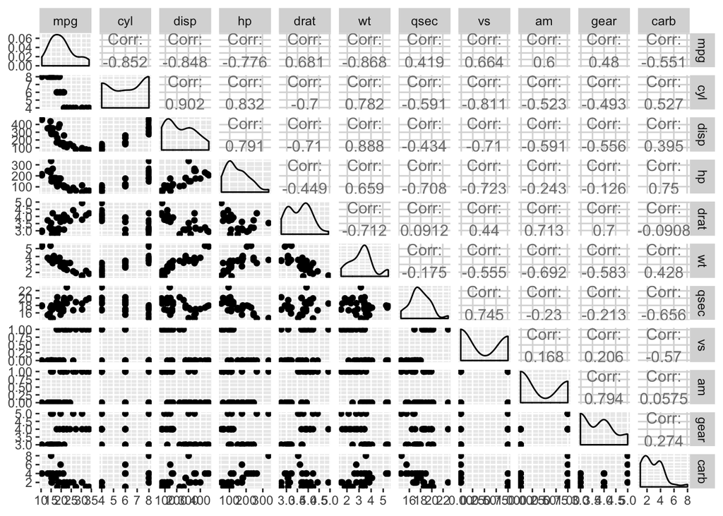

```r
ggpairs(mtcars)
```

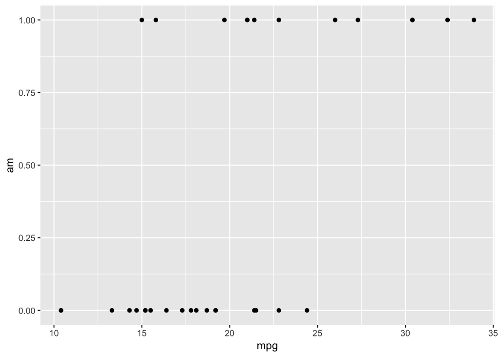

```r
ggplot(data = mtcars, aes(y =am, x = mpg))+
  geom_point()
```

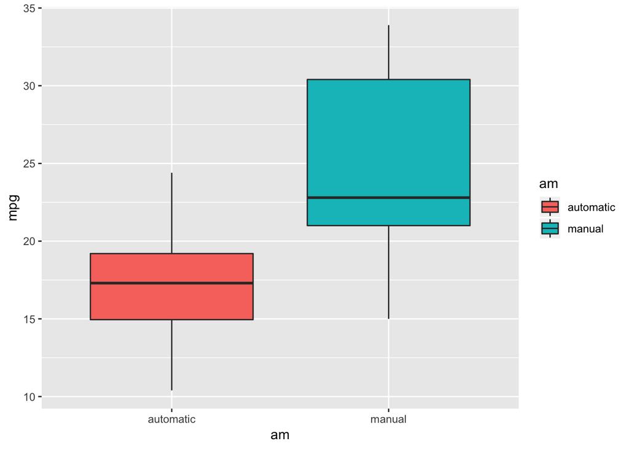

```r
ggplot(data = data)+
  aes(x = am, y = mpg,fill=am)+
  geom_boxplot()
```

REISIDUAL PLOT FOR MODEL 2

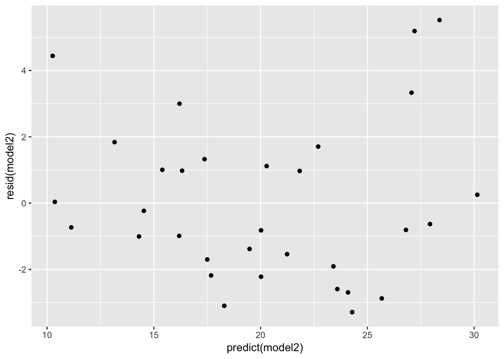

```r
qplot(predict(model2), resid(model2))
```